# Competitive Data Science & Solutions Project

William Rice

02/26/24

# Introduction

The purpose of this project is to gauge your technical skills and problem solving ability by working through something similar to a real NBA data science project. You will work your way through this R Markdown document, answering questions as you go along. Please begin by adding your name to the “author” key in the YAML header. When you’re finished with the document, come back and type your answers into the answer key at the top. Please leave all your work below and have your answers where indicated below as well. Please note that we will be reviewing your code so make it clear, concise and avoid long printouts. Feel free to add in as many new code chunks as you’d like.

Remember that we will be grading the quality of your code and visuals alongside the correctness of your answers. Please try to use the tidyverse as much as possible (instead of base R and explicit loops.)

**Note:**

**Throughout this document, any `season` column represents the year each season started. For example, the 2015-16 season will be in the dataset as 2015. For most of the rest of the project, we will refer to a season by just this number (e.g. 2015) instead of the full text (e.g. 2015-16).**

# Answers

## Part 1

**Question 1:**

**Question 2:** 4.7 Years

**Question 3:**

- Elite: 2 players.
- All-Star: 1 players.
- Starter: 10 players.
- Rotation: 8 players.
- Roster: 14 players.
- Out of League: 38 players.

**Open Ended Modeling Question:** Please show your work and leave all responses below in the document.

## Part 2

**Question 1:** 28.9% **Question 2:** Written question, put answer below in the document. **Question 3:** Written question, put answer below in the document.

# Setup and Data

```r
library(tidyverse)
# Note, you will likely have to change these paths. If your data is in the same folder as this project,
# the paths will likely be fixed for you by deleting ../../Data/awards_project/ from each string.
awards <- read_csv("awards_data.csv")
player_data <- read_csv("player_stats.csv")
team_data <- read_csv("team_stats.csv")
rebounding_data <- read_csv("team_rebounding_data_22.csv")
```

## Part 1 – Awards

In this section, you’re going to work with data relating to player awards and statistics. You’ll start with some data manipulation questions and work towards building a model to predict broad levels of career success.

### Question 1

**QUESTION:** What is the average number of points per game for players in the 2007-2021 seasons who won All NBA First, Second, and Third teams (**not** the All Defensive Teams), as well as for players who were in the All-Star Game (**not** the rookie all-star game)?

```r
# Here and for all future questions, feel free to add as many code chunks as you like. Do NOT put echo = F though, we'll want to see your code.
```

```r
#I am using seperate code chunks to represent my work on data manipulation, then one code chunk for each of the 4 different values asked for#
#I joined the awards and player statistics datasets together to have all relevant information on one dataset, doing so by the common season and nbapersonid features. Then, I created a points per game variable (ppg), as I will need it for the answers for question 1, by dividing total points that season by games.#
library(dplyr)
part1df <- player_data %>% inner_join(awards,
        by=c('nbapersonid'='nbapersonid', 'season'='season'), relationship = 'many-to-many') %>%
  mutate(ppg=points/games)
```

```r
#For each of the next 4 chunks, I created a smaller subset that only inclued players selected to the specific honors team asked for. I then used summarize to average out ppg for each player and report it back as a single value.# I did this for all 4 values identically.#
#1st Team Work#
first_team_ppg <- part1df %>%
  filter(`All NBA First Team` == 1) %>%
  summarize(mean_ppg1 = mean(ppg))
first_team_ppg
```

```
## # A tibble: 1 × 1
##   mean_ppg1
##       <dbl>
## 1      25.9
```

```r
#2nd Team Work#
second_team_ppg <- part1df %>%
  filter(`All NBA Second Team` == 1) %>%
  summarize(mean_ppg2 = mean(ppg))
second_team_ppg
```

```
## # A tibble: 1 × 1
##   mean_ppg2
##       <dbl>
## 1      23.1
```

```r
#3rd Team Work#
third_team_ppg <- part1df %>%
  filter(`All NBA Third Team` == 1) %>%
  summarize(mean_ppg3 = mean(ppg))
third_team_ppg
```

```
## # A tibble: 1 × 1
##   mean_ppg3
##       <dbl>
## 1      20.5
```

```r
#All-Star Work#
all_star_ppg <- part1df %>%
  filter(`all_star_game` == 'TRUE') %>%
  summarize(mean_ppg4 = mean(ppg))
all_star_ppg
```

```
## # A tibble: 1 × 1
##   mean_ppg4
##       <dbl>
## 1      21.6
```

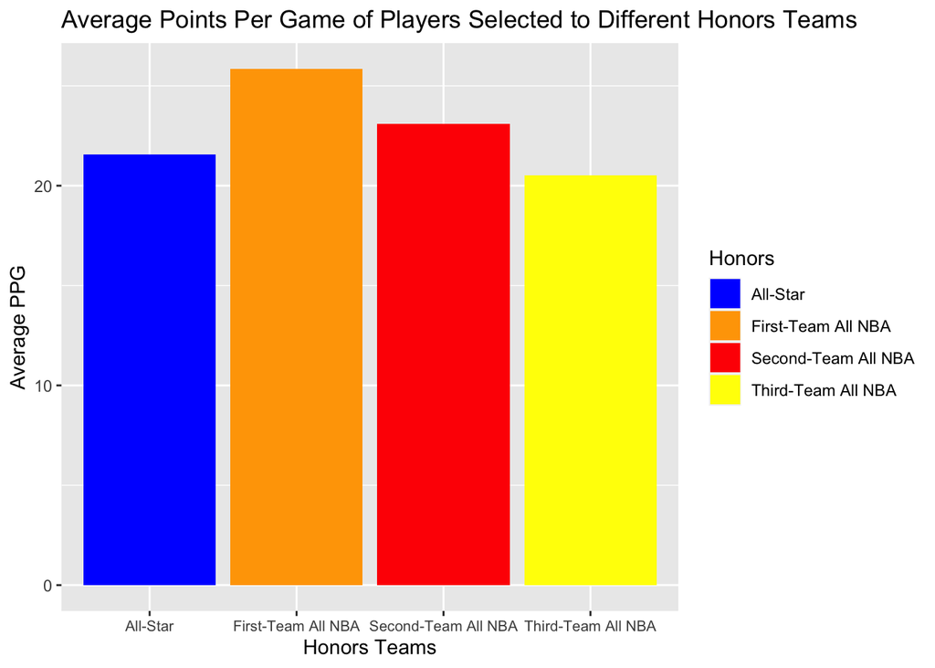

```r
#I made a graph on top of the 4 values shown just to visualize the differences in average ppg across different all-nba teams and all-star teams (and perhaps to do a little extra!). I used a dataframe to store each of the four values corresponding to the honors team, and also added custom colors for each one. Using ggplot and some of its features I was able to make a small plot for all four values, as shown below.#


honors_team <- c("First-Team All NBA", "Second-Team All NBA", "Third-Team All NBA", "All-Star")
avg_ppg <- c(sum(first_team_ppg), sum(second_team_ppg), sum(third_team_ppg), sum(all_star_ppg))

avg_ppg_plot_data <- data.frame(Honors = honors_team, PPG = avg_ppg)

plot_colors <- c('All-Star' = "blue", 'First-Team All NBA' = "orange", 'Second-Team All NBA' = "red", 'Third-Team All NBA' = "yellow")

ggplot(avg_ppg_plot_data, aes(x = Honors, y = PPG, fill = Honors)) +
  geom_bar(stat = "identity") +
  scale_fill_manual(values = plot_colors) +
  labs(title = "Average Points Per Game of Players Selected to Different Honors Teams", x = "Honors Teams", y = "Average PPG") +
  theme(axis.text.x = element_text(size = 8))
```

**ANSWER 1:**

### Question 2

**QUESTION:** What was the average number of years of experience in the league it takes for players to make their first All NBA Selection (1st, 2nd, or 3rd team)? Please limit your sample to players drafted in 2007 or later who did eventually go on to win at least one All NBA selection. For example:

- Luka Doncic is in the dataset as 2 years. He was drafted in 2018 and won his first All NBA award in 2019 (which was his second season).
- LeBron James is not in this dataset, as he was drafted prior to 2007.
- Lu Dort is not in this dataset, as he has not received any All NBA honors.

```r
#I took the large dataset that had combined player and awards statistics, and I filtered it so it would only show players drafted after 2006, and those who have been on any All-NBA team. I then created a new variable that calculated how long it took for each record to record their All-NBA selection from the draft year. I had to add a '+1' as people play in the same year they are drafted, and are given the award the end of the last year that counts, meaning that if I were to not add the plus one it would be a year behind. For example, if someone were to ever be named to an All-NBA team their rookie year, without the +1 it would show 0 years, which is impossible. The +1 was necessary due to the data. Then, I grouped each player by their name, and filtered the data so it would only show the first season they recieved an award. This was the variable being asked for, so I then averaged it out across all players and found the answer.#


mean_years_experience <- part1df %>%
  filter(draftyear > 2006,
         `All NBA First Team` == 1 | `All NBA Second Team` == 1 | `All NBA Third Team` == 1) %>%
  mutate(years_until_allNBA = season - draftyear + 1) %>%
  group_by(player) %>%
  filter(season == min(season)) %>%
  ungroup() %>%
  summarize(mean_years = mean(years_until_allNBA))

mean_years_experience
```

```
## # A tibble: 1 × 1
##   mean_years
##        <dbl>
## 1       4.67
```

**ANSWER 2:**

4.7 Years

## Data Cleaning Interlude

You’re going to work to create a dataset with a “career outcome” for each player, representing the highest level of success that the player achieved for **at least two** seasons *after his first four seasons in the league* (examples to follow below!). To do this, you’ll start with single season level outcomes. On a single season level, the outcomes are:

- Elite: A player is “Elite” in a season if he won any All NBA award (1st, 2nd, or 3rd team), MVP, or DPOY in that season.
- All-Star: A player is “All-Star” in a season if he was selected to be an All-Star that season.
- Starter: A player is a “Starter” in a season if he started in at least 41 games in the season OR if he played at least 2000 minutes in the season.
- Rotation: A player is a “Rotation” player in a season if he played at least 1000 minutes in the season.
- Roster: A player is a “Roster” player in a season if he played at least 1 minute for an NBA team but did not meet any of the above criteria.
- Out of the League: A player is “Out of the League” if he is not in the NBA in that season.

We need to make an adjustment for determining Starter/Rotation qualifications for a few seasons that didn’t have 82 games per team. Assume that there were 66 possible games in the 2011 lockout season and 72 possible games in each of the 2019 and 2020 seasons that were shortened due to covid. Specifically, if a player played 900 minutes in 2011, he **would** meet the rotation criteria because his final minutes would be considered to be 900 * (82/66) = 1118. Please use this math for both minutes and games started, so a player who started 38 games in 2019 or 2020 would be considered to have started 38 * (82/72) = 43 games, and thus would qualify for starting 41. Any answers should be calculated assuming you round the multiplied values to the nearest whole number.

Note that on a season level, a player’s outcome is the highest level of success he qualifies for in that season. Thus, since Shai Gilgeous-Alexander was both All-NBA 1st team and an All-Star last year, he would be considered to be “Elite” for the 2022 season, but would still qualify for a career outcome of All-Star if in the rest of his career he made one more All-Star game but no more All-NBA teams. Note this is a hypothetical, and Shai has not yet played enough to have a career outcome.

Examples:

- A player who enters the league as a rookie and has season outcomes of Roster (1), Rotation (2), Rotation (3), Roster (4), Roster (5), Out of the League (6+) would be considered “Out of the League,” because after his first four seasons, he only has a single Roster year, which does not qualify him for any success outcome.
- A player who enters the league as a rookie and has season outcomes of Roster (1), Rotation (2), Starter (3), Starter (4), Starter (5), Starter (6), All-Star (7), Elite (8), Starter (9) would be considered “All-Star,” because he had at least two seasons after his first four at all-star level of production or higher.
- A player who enters the league as a rookie and has season outcomes of Roster (1), Rotation (2), Starter (3), Starter (4), Starter (5), Starter (6), Rotation (7), Rotation (8), Roster (9) would be considered a “Starter” because he has two seasons after his first four at a starter level of production.

### Question 3

**QUESTION:** There are 73 players in the `player_data` dataset who have 2010 listed as their draft year. How many of those players have a **career** outcome in each of the 6 buckets?

```r
#Note: In the following r code chunk, I am very aware this is not concise. This took me a long time to figure out, and while I am most likely sure there were multiple ways to find this easier, this was the only possible way I found to get the second highest season outcome when the frequency of the highest season outcome where I could then combine them with the myriad of ifelse statements you see below. Again, I am aware this may ding me for potential conciseness and correctness, but overall I do believe my thought process of how to complete that last question as well as my range of r knowledge in both tidyverse and base r was shown. Hopefully you understand with a bit more of a time-crunch my reasoning for this explanation but I hope this suffices! -Will Rice#
```

```r
#I created a new function altogether that would account for those specific seasons needing to be altered as due to the lockout and covid halts in play, respectively. I used if else so as to not change the other seasons that were not changed in terms of max games played.#

calculate_mins <- function(mins, season) {
  ifelse(season == 2011, mins * (82/66), ifelse(season %in% c(2019, 2020), mins * (82/72), mins))
}

#Next, I once again joined the two datasets together for a fresh new dataset, so I can create the main variable in question: Highest Outcome. I followed the specific criteria asked for in terms of different outcomes using the case_when function, then implemented my new minutes/games variable to alter those 3 seasons' minutes/games values. I also rounded them as the first time I viewed the dataset it looked off as all of the other data in other years was nice and rounded. Then, I filtered for the 2010 draft year, as that was part of the question asked, and excluded all player's first four years since being drafted as those did not count towards a career outcome. I filtered by player and season and made sure there were no duplicate years: tehre were players traded midway through the season they had duplicated values that would count for them and in most cases help them get two seasons worth of similar playing time or better, which would not be fair, as that only occurred in one seaosn. Thus, I filtered so only one would show up. Then I grouped by player and their highest outcome, and found their frequency for each outcome, which was ranked in the order I told r to rank using the arrange(match) function. Then grouping by player, I used the slice function to find the highest outcome each player had during their 5th year and beyond. If that outcome had a frequency of 2, it was lsited as their highest outcome. If their highest outcome was roster with a frequency of 1, they were listed as out of the league for the logical reasons that the second lowest with only one outcome means the other years they could only be out of the league. Evryone else was NA. I explain my next process below.#


career_outcomes <- player_data %>%
  left_join(awards, by = c("nbapersonid", "season"), relationship = 'many-to-many') %>%
  mutate(HighestOutcome = case_when(
    `All NBA First Team` == 1 | `All NBA Second Team` == 1 | `All NBA Third Team` == 1 |
    `Most Valuable Player_rk` == 1 | `Defensive Player Of The Year_rk` == 1 ~ "Elite",
    all_star_game == 'TRUE' ~ "All-Star",
    games_start >= 41 | mins >= 2000 ~ "Starter",
    mins >= 1000 ~ "Rotation",
    mins >= 1 ~ "Roster",
    TRUE ~ "Out of the League"
  )) %>%
  mutate(mins = calculate_mins(mins, season),
         games_start = calculate_mins(games_start, season),
         mins = as.integer(round(mins)),
         games_start = as.integer(round(games_start))) %>%
  filter(season >= draftyear + 4, draftyear == 2010) %>%
  group_by(player, season) %>%
  filter(row_number() == 1) %>%
  ungroup() %>%
  group_by(player, HighestOutcome) %>%
  summarize(Frequency = n(), .groups = "keep") %>%
  arrange(match(HighestOutcome, c("Elite", "All-Star", "Starter", "Rotation", "Roster", "Out of the League"))) %>%
  group_by(player) %>%
  slice(1) %>%
  mutate(CareerOutcome = if_else(Frequency >= 2, HighestOutcome, NA),
         CareerOutcome = if_else(HighestOutcome == 'Roster' & Frequency == 1, 'Out of League', CareerOutcome)) %>%
  group_by(player) %>%
  ungroup()

#This is where I was left frustrated and ended up happy with the outcome, though I realize I can get cluttered in how often i'm creating new datasets. I created another datatset, identical to the previous in every way. Up until I create the secondhighestoutcome variable, it is mostly the same process. I created secondhighestoutcome, which is the same as highest outcome except using some if_else statements and named differently for reasons named later. Next, I counted frequencies and listed importance of eadch outcome in order once more, except used slice function this time to find the second highest outcome for each player. I joined the two datasets together that listed each players highest and second highest outcome (although it only listed the highest if the frequency was > 1 and the rest were NA). Deselecting the frequencies then left me with a simple dataset of each player and their outcomes.



single_season_outcomes <- player_data %>%
  left_join(awards, by = c("nbapersonid", "season"), relationship = 'many-to-many') %>%
  mutate(Elite = (`All NBA First Team` == 1 | `All NBA Second Team` == 1 | `All NBA Third Team` == 1 | `Defensive Player Of The Year_rk` == 1 | `Most Valuable Player_rk` == 1) + 0,
  Elite = ifelse(is.na(Elite), 0, Elite)) %>%
  mutate(AllStar = (all_star_game == 'TRUE' & Elite == 0) + 0,
  AllStar = ifelse(is.na(AllStar), 0, AllStar)) %>%
  mutate(Starter = ((games_start > 40 | mins > 1999) & Elite == 0 & AllStar == 0) + 0,
  Starter = ifelse(is.na(Starter), 0, Starter)) %>%
  mutate(Rotation = (mins > 999 & Elite == 0 & AllStar == 0 & Starter == 0) + 0,
  Rotation = ifelse(is.na(Rotation), 0, Rotation)) %>%
  mutate(Roster = (mins > 0 & Elite == 0 & AllStar == 0 & Starter == 0 & Rotation == 0) + 0,
  Roster = ifelse(is.na(Roster), 0, Roster)) %>%
  mutate(OutOfLeague = ifelse(Elite == 0 & AllStar == 0 & Starter == 0 & Rotation == 0 & Roster == 0, 1, 0)) %>%
  mutate(mins = if_else(season == 2011, mins*(82/66), mins)) %>%
  mutate(mins = if_else(season == 2019|season == 2020, mins*(82/72), mins)) %>%
  mutate(games_start = if_else(season == 2011, games_start*(82/66), games_start)) %>%
  mutate(games_start = if_else(season == 2019|season == 2020, games_start*(82/72), games_start)) %>%
  mutate(mins = as.integer(round(mins))) %>%
  mutate(games_start = as.integer(round(games_start))) %>%
  select(nbapersonid, draftyear, player, season, Elite, AllStar, Starter, Rotation, Roster, OutOfLeague) %>%
  filter(draftyear == 2010, season > 2013) %>%
  group_by(player, season) %>%
  filter(row_number() == 1) %>%
  ungroup() %>%
  mutate(SecondHighestOutcome = if_else(Elite == 1, 'Elite', if_else(AllStar == 1, 'All-Star', if_else(Starter == 1, 'Starter', if_else(Rotation == 1, 'Rotation', if_else(Roster == 1, 'Roster', 'Out of League')))))) %>%
  group_by(player, SecondHighestOutcome) %>%
  summarize(Frequency = n(), .groups = "keep") %>%
  arrange(match(SecondHighestOutcome, c("Elite", "All-Star", "Starter", "Rotation", "Roster", "Out of the League"))) %>%
  group_by(player) %>%
  slice(2)

second_highest_outcomes <- single_season_outcomes


total_2010_outcomes <- left_join(career_outcomes, second_highest_outcomes, by = "player") %>%
  select(-Frequency.x, -Frequency.y) %>%
  mutate(CareerOutcome = if_else(is.na(CareerOutcome), SecondHighestOutcome, CareerOutcome)) %>%
  select(-SecondHighestOutcome)


#I replaced all NA values in the highest outcome with its second highest outcome, and then deselected second highest outcome. Next, I used the summarize function to count how many of each career outcome the 2010 draft class had. I also noticed I only retained 44 values after the 4 year of playing. This meant that if I were given the value 73, and only 44 had a distinct outcome, there were 29 who never played in their fifth year, and thus automatically qualify as out of league. I created a variable that counted 29 more out of leagues in the main dataset, and created one table 'outcome_counts' that showed the counts of all 6 different outcomes for the 2010 draft class.


outcome_counts <- total_2010_outcomes %>%
  group_by(CareerOutcome) %>%
  summarize(count = n())

out_of_league_before_5th_year <- data.frame(CareerOutcome = "Out of League", count = 29)

outcome_counts <- bind_rows(outcome_counts, out_of_league_before_5th_year) %>%
  group_by(CareerOutcome) %>%
  summarize(count = sum(count))
outcome_counts
```

```
## # A tibble: 6 × 2
##   CareerOutcome count
##   <chr>         <dbl>
## 1 All-Star          1
## 2 Elite             2
## 3 Out of League    38
## 4 Roster           14
## 5 Rotation          8
## 6 Starter          10
```

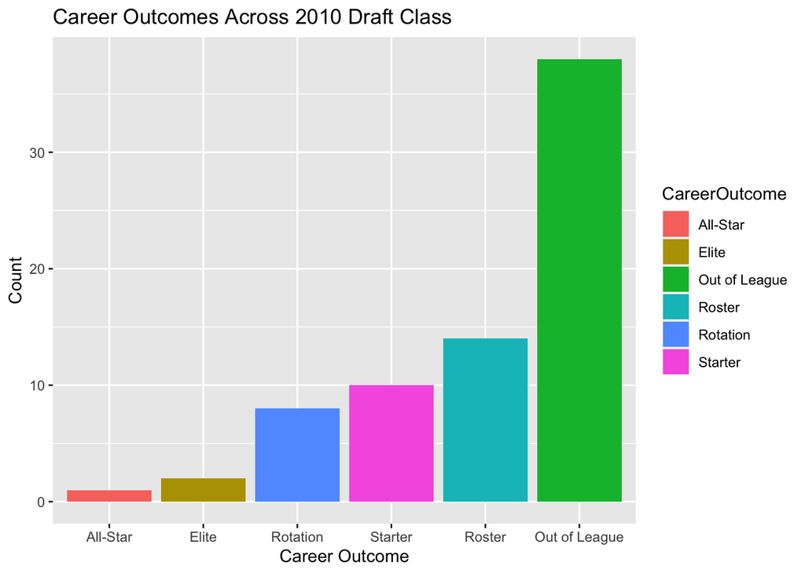

```r
#Next, I created again a ggplot visual to show counts by outcome, just to display how hard it is to not only stay in the league, but thrive! I thought with some interesting colors generically given that it made for a nice additive to this otherwise code-heavy question due to my trouble withbthe second highest outcome.#

ggplot(outcome_counts, aes(x = reorder(CareerOutcome, count), y = count, fill = CareerOutcome)) +
  geom_bar(stat = "identity") +
  labs(x = "Career Outcome", y = "Count", title = "Career Outcomes Across 2010 Draft Class")
```

**ANSWER 3:**

Elite: 2 players.  
All-Star: 1 players.  
Starter: 10 players.  
Rotation: 8 players.  
Roster: 14 players.  
Out of League: 38 players.

### Open Ended Modeling Question

In this question, you will work to build a model to predict a player’s career outcome based on information up through the first four years of his career.

This question is intentionally left fairly open ended, but here are some notes and specifications.

1. We know modeling questions can take a long time, and that qualified candidates will have different levels of experience with “formal” modeling. Don’t be discouraged. It’s not our intention to make you spend excessive time here. If you get your model to a good spot but think you could do better by spending a lot more time, you can just write a bit about your ideas for future improvement and leave it there. Further, we’re more interested in your thought process and critical thinking than we are in specific modeling techniques. Using smart features is more important than using fancy mathematical machinery, and a successful candidate could use a simple regression approach.
2. You may use any data provided in this project, but please do not bring in any external sources of data. Note that while most of the data provided goes back to 2007, All NBA and All Rookie team voting is only included back to 2011.
3. A player needs to complete at least three additional seasons after their first four to be considered as having a distinct career outcome for our dataset. (We are using 3+ instead of 2+ just to give each player a little more time to accumulate high level seasons before we classify his career). Because the dataset in this project ends in 2021, this means that a player would need to have had the chance to play in the ’21, ’20, and ’19 seasons after his first four years, and thus his first four years would have been ’18, ’17, ’16, and ’15. **For this reason, limit your training data to players who were drafted in or before the 2015 season.** Karl-Anthony Towns was the #1 pick in that season.
4. Once you build your model, predict on all players who were drafted in 2018-2021 (They have between 1 and 4 seasons of data available and have not yet started accumulating seasons that inform their career outcome).
5. You can predict a single career outcome for each player, but it’s better if you can predict the probability that each player falls into each outcome bucket.
6. Include, as part of your answer:
- A brief written overview of how your model works, targeted towards a decision maker in the front office without a strong statistical background.
- What you view as the strengths and weaknesses of your model.
- How you’d address the weaknesses if you had more time and or more data.
- A ggplot or ggplotly visualization highlighting some part of your modeling process, the model itself, or your results.
- Your predictions for Shai Gilgeous-Alexander, Zion Williamson, James Wiseman, and Josh Giddey.
- (Bonus!) An html table (for example, see the package `reactable`) containing all predictions for the players drafted in 2019-2021.

```r
#Again, I created a master dataset that joined together awards and player data, mutating any value that was NA into a 0. The, I went back and remedied a few choice columns: draftpick was given an NA again if the value was 0, as was all nba and all rookie voting ranks before 2011, as there was no data. Then, I created some average statistics and rounded them to one decimal point, while I deselected some of the stats I did not believe had any independent, significant correlation to a potential career outcome, or that were already a part of another lumped variable.


#MODEL DATASET#

model_data <- left_join(player_data, awards, by = c("nbapersonid", "season"), relationship = 'many-to-many') %>%
  mutate_all(~ replace(., is.na(.), 0)) %>%
  mutate(draftpick = if_else(draftpick == 0, NA, draftpick)) %>%
  mutate(all_nba_points_rk = if_else(all_nba_points_rk == 0 & season < 2011, NA, all_nba_points_rk)) %>%
  mutate(all_rookie_points_rk = if_else(all_rookie_points_rk == 0 & season < 2011, NA, all_rookie_points_rk)) %>%
  filter(draftyear >= 2003) %>%
  mutate(ppg = (points/games)) %>%
  mutate(rpg = (tot_reb/games)) %>%
  mutate(apg = (ast/games)) %>%
  mutate(bpg = (blocks/games)) %>%
  mutate(spg = (steals/games)) %>%
  mutate_at(vars(apg, spg, bpg, ppg, rpg), ~ round(., 1)) %>%
  select(-draftpick, -nbateamid, -'Player Of The Month', -'Rookie Of The Month', -'Player Of The Week', -all_nba_points_rk, -all_rookie_points_rk, -allstar_rk)

model_data
```

```
## # A tibble: 7,279 × 67
##    nbapersonid player draftyear season team  games games_start  mins   fgm   fga
##          <dbl> <chr>      <dbl>  <dbl> <chr> <dbl>       <dbl> <dbl> <dbl> <dbl>
##  1        2585 Zaza …      2003   2007 ATL      62           5   944   107   245
##  2      200780 Solom…      2006   2007 ATL      35           0   145    12    30
##  3        2746 Josh …      2004   2007 ATL      81          81  2873   518  1133
##  4      201151 Acie …      2007   2007 ATL      56           6   865    95   237
##  5      101136 Salim…      2005   2007 ATL      35           0   402    65   180
##  6        2735 Josh …      2004   2007 ATL      76           0  2274   327   573
##  7      200978 Jerem…      2006   2007 ATL      19           0    88    13    31
##  8      201143 Al Ho…      2007   2007 ATL      81          77  2540   333   668
##  9      101107 Marvi…      2005   2007 ATL      80          80  2765   424   918
## 10      200749 Sheld…      2006   2007 ATL      36           0   414    37   100
## # ℹ 7,269 more rows
## # ℹ 57 more variables: fgp <dbl>, fgm3 <dbl>, fga3 <dbl>, fgp3 <dbl>,
## #   fgm2 <dbl>, fga2 <dbl>, fgp2 <dbl>, efg <dbl>, ftm <dbl>, fta <dbl>,
## #   ftp <dbl>, off_reb <dbl>, def_reb <dbl>, tot_reb <dbl>, ast <dbl>,
## #   steals <dbl>, blocks <dbl>, tov <dbl>, tot_fouls <dbl>, points <dbl>,
## #   PER <dbl>, FTr <dbl>, off_reb_pct <dbl>, def_reb_pct <dbl>,
## #   tot_reb_pct <dbl>, ast_pct <dbl>, stl_pct <dbl>, blk_pct <dbl>, …
```

```r
calculate_mins <- function(mins, season) {
  ifelse(season == 2011, mins * (82/66), ifelse(season %in% c(2019, 2020), mins * (82/72), mins))
}


#Next, I made my training dataset. I took the model dataset and filtered out only players drafted between 2007 to 2015. This was imperative to me as to have all of the first four years of data on every players career available, as well as the years beyond that which made to help generate a distinct outcome. For the next few chunks of code, I reproduced finding the highest career outcome after doing some duplicate codes to ensure there wjere no 'NA's left with the next highest seaosnal outcome.


#TRAINING DATASET#

training_set <- model_data %>%
  filter(draftyear < 2016 & draftyear > 2006) %>%
  mutate(SeasonOutcome = case_when(
    `All NBA First Team` == 1 | `All NBA Second Team` == 1 | `All NBA Third Team` == 1 |
    `Most Valuable Player_rk` == 1 | `Defensive Player Of The Year_rk` == 1 ~ "Elite",
    all_star_game == 1 ~ "All-Star",
    games_start >= 41 | mins >= 2000 ~ "Starter",
    mins >= 1000 ~ "Rotation",
    mins >= 1 ~ "Roster",
    TRUE ~ "Out of the League"
  )) %>%
  mutate(mins = calculate_mins(mins, season),
         games_start = calculate_mins(games_start, season),
         mins = as.integer(round(mins)),
         games_start = as.integer(round(games_start))) %>%
  filter(season >= draftyear + 4) %>%
  group_by(player, season) %>%
  filter(row_number() == 1) %>%
  ungroup() %>%
  group_by(player, SeasonOutcome) %>%
  summarize(Frequency = n(), .groups = "keep") %>%
  arrange(match(SeasonOutcome, c("Elite", "All-Star", "Starter", "Rotation", "Roster", "Out of the League"))) %>%
  group_by(player) %>%
  slice(1) %>%
  mutate(CareerOutcome = if_else(Frequency >= 3, SeasonOutcome, NA),
         CareerOutcome = if_else(SeasonOutcome == 'Roster' & Frequency == 1, 'Out of League', CareerOutcome)) %>%
  group_by(player) %>%
  ungroup()


training_data_2 <- model_data %>%
  filter(draftyear < 2016 & draftyear > 2006) %>%
  mutate(SecondHighestSeasonOutcome = case_when(
    `All NBA First Team` == 1 | `All NBA Second Team` == 1 | `All NBA Third Team` == 1 |
    `Most Valuable Player_rk` == 1 | `Defensive Player Of The Year_rk` == 1 ~ "Elite",
    all_star_game == 1 ~ "All-Star",
    games_start >= 41 | mins >= 2000 ~ "Starter",
    mins >= 1000 ~ "Rotation",
    mins >= 1 ~ "Roster",
    TRUE ~ "Out of the League"
  )) %>%
  mutate(mins = calculate_mins(mins, season),
         games_start = calculate_mins(games_start, season),
         mins = as.integer(round(mins)),
         games_start = as.integer(round(games_start))) %>%
  filter(season >= draftyear + 4) %>%
  group_by(player, season) %>%
  filter(row_number() == 1) %>%
  ungroup() %>%
  group_by(player, SecondHighestSeasonOutcome) %>%
  summarize(Frequency = n(), .groups = "keep") %>%
  arrange(match(SecondHighestSeasonOutcome, c("Elite", "All-Star", "Starter", "Rotation", "Roster", "Out of the League"))) %>%
  group_by(player) %>%
  slice(2)




training_data_third_highest <- model_data %>%
  filter(draftyear < 2016 & draftyear > 2006) %>%
  mutate(ThirdHighestSeasonOutcome = case_when(
    `All NBA First Team` == 1 | `All NBA Second Team` == 1 | `All NBA Third Team` == 1 |
    `Most Valuable Player_rk` == 1 | `Defensive Player Of The Year_rk` == 1 ~ "Elite",
    all_star_game == 1 ~ "All-Star",
    games_start >= 41 | mins >= 2000 ~ "Starter",
    mins >= 1000 ~ "Rotation",
    mins >= 1 ~ "Roster",
    TRUE ~ "Out of the League"
  )) %>%
  mutate(mins = calculate_mins(mins, season),
         games_start = calculate_mins(games_start, season),
         mins = as.integer(round(mins)),
         games_start = as.integer(round(games_start))) %>%
  filter(season >= draftyear + 4) %>%
  group_by(player, season) %>%
  filter(row_number() == 1) %>%
  ungroup() %>%
  group_by(player, ThirdHighestSeasonOutcome) %>%
  summarize(Frequency = n(), .groups = "keep") %>%
  arrange(match(ThirdHighestSeasonOutcome, c("Elite", "All-Star", "Starter", "Rotation", "Roster", "Out of the League"))) %>%
  group_by(player) %>%
  slice(3)

View(training_data_third_highest)


total_training_outcomes_draft <- left_join(training_set, training_data_2, by = "player") %>%
  mutate(CareerOutcome = if_else(Frequency.x == 1, if_else(Frequency.y <= 1, NA, SecondHighestSeasonOutcome), CareerOutcome)) %>%
  mutate(CareerOutcome = if_else(Frequency.x == 2, SecondHighestSeasonOutcome, CareerOutcome)) %>%
  mutate(CareerOutcome = if_else(is.na(CareerOutcome) & is.na(SecondHighestSeasonOutcome), "Out of League", CareerOutcome))
View(total_training_outcomes_draft)



total_training_outcomes <- left_join(total_training_outcomes_draft, training_data_third_highest, by = "player") %>%
  select(-SecondHighestSeasonOutcome, -Frequency.y) %>%
  mutate(CareerOutcome = if_else(is.na(CareerOutcome) & is.na(ThirdHighestSeasonOutcome), "Out of League", CareerOutcome)) %>%
  mutate(CareerOutcome = if_else(is.na(CareerOutcome), ThirdHighestSeasonOutcome, CareerOutcome))

View(total_training_outcomes)


#I then joined to gether the dataset of all players drafted from 2007 and 2015 with the players with distinct career outcomes, and then filtered all players who did not play long enough to 'Out of League.' This became the base for my training data.

training_data_3 <- model_data %>%
  filter(draftyear < 2016 & draftyear > 2006)

training_dataset_main <- left_join(training_data_3, total_training_outcomes, by = "player") %>%
  mutate(CareerOutcome = if_else(is.na(CareerOutcome) & is.na(SeasonOutcome), 'Out of League', CareerOutcome)) %>%
  select(-SeasonOutcome)
View(training_dataset_main)



#I then took their first four years of data as the training data. This is because we are predicting on the test data's first one-four years of data to make a prediction. We have career outcomes for each of these players, and we can also aggregate their first four years to build a model that can help us evaluate the test dat to find similar trends in variables and data. I took the next massive few chunks of code to create aggregated statistics over the first four years of each players career. I believed having one record for each player in summation may be able to fit into a model better, and it just took a bit of time to write down every stat so as to average it out correctly.
```

```r
first_4_years <- training_dataset_main %>%
  filter(season <= draftyear + 3) %>%
  group_by(player, season) %>%
  filter(row_number() == 1) %>%
  ungroup() %>%
  mutate(MVP_Award = if_else(`Most Valuable Player_rk` == 1, 1, 0)) %>%
  mutate(MVP_Candidate = if_else(`Most Valuable Player_rk` > 1 & `Most Valuable Player_rk` < 10, 1, 0)) %>%
  mutate(MIP_Award = if_else(`Most Improved Player_rk` == 1, 1, 0)) %>%
  mutate(MIP_Candidate = if_else(`Most Improved Player_rk` > 1 & `Most Improved Player_rk` < 10, 1, 0)) %>%
  mutate(DPOY_Award = if_else(`Defensive Player Of The Year_rk` == 1, 1, 0)) %>%
  mutate(DPOY_Candidate = if_else(`Defensive Player Of The Year_rk` > 1 & `Defensive Player Of The Year_rk` < 10, 1, 0)) %>%
  mutate(ROY_Award = if_else(`Rookie Of The Year_rk` == 1, 1, 0)) %>%
  mutate(ROY_Candidate = if_else(`Rookie Of The Year_rk` > 1 & `Rookie Of The Year_rk` < 10, 1, 0)) %>%
  mutate(Sixth_Man_Award = if_else(`Sixth Man Of The Year_rk` == 1, 1, 0)) %>%
  mutate(Sixth_Man_Candidate = if_else(`Sixth Man Of The Year_rk` > 1 & `Sixth Man Of The Year_rk` < 10, 1, 0))

first_4_years_training <- first_4_years %>%
  group_by(player) %>%
  summarize(
    all_star_games = sum(all_star_game),
    all_nba_defensive_first_team_selections = sum(`All NBA Defensive First Team`),
    all_nba_defensive_second_team_selections = sum(`All NBA Defensive Second Team`),
    all_nba_first_team_selections = sum(`All NBA First Team`),
    all_nba_second_team_selections = sum(`All NBA Second Team`),
    all_nba_third_team_selections = sum(`All NBA Third Team`),
    all_rookie_first_team_selections = sum(`All Rookie First Team`),
    all_rookie_second_team_selections = sum(`All Rookie Second Team`),
    MVP_count = sum(`MVP_Award`),
    MIP_count = sum(`MIP_Award`),
    DPOY_count = sum(`DPOY_Award`),
    ROY_count = sum(`ROY_Award`),
    sixth_man_count = sum(`Sixth_Man_Award`),
    MVP_candidate_count = sum(`MVP_Candidate`),
    MIP_candidate_count = sum(`MIP_Candidate`),
    DPOY_candidate_count = sum(`DPOY_Candidate`),
    ROY_candidate_count = sum(`ROY_Candidate`),
    sixth_man_candidate_count = sum(`Sixth_Man_Candidate`),
    finals_mvp = sum(`Bill Russell NBA Finals MVP`),
    total_points = sum(points),
    total_assists = sum(points),
    total_rebounds = sum(tot_reb),
    total_steals = sum(steals),
    total_blocks = sum(blocks),
    total_turnovers = sum(tov),
    total_field_goals = sum(fgm),
    total_field_goals_attempted = sum(fga),
    total_two_pointers = sum(fgm2),
    total_two_pointers_attempted = sum(fga2),
    total_three_pointers = sum(fgm3),
    total_three_pointers_attempted = sum(fga3),
    total_free_throws = sum(ftm),
    total_free_throws_attempted = sum(fta),
    total_games_started = sum(games_start),
    total_minutes = sum(mins),
    total_defensive_win_shares = sum(DWS),
    total_offensive_win_shares = sum(OWS),
    total_win_shares = sum(WS),
    total_defensive_box_plus_minus = sum(DBPM),
    total_offensive_box_plus_minus = sum(OBPM),
    total_box_plus_minus = sum(BPM),
    total_VORP = sum(VORP),
    total_games = sum(games),
    total_PER = sum(PER),
    total_usg = sum(usg)

  )


first_4_years_aggregated <- first_4_years_training %>%
  mutate(ppg = (total_points/total_games)) %>%
  mutate(apg = (total_assists/total_games)) %>%
  mutate(rpg = (total_rebounds/total_games)) %>%
  mutate(bpg = (total_blocks/total_games)) %>%
  mutate(spg = (total_steals/total_games)) %>%
  mutate(topg = (total_turnovers/total_games)) %>%
  mutate(fgpg = (total_field_goals/total_games)) %>%
  mutate(fgapg = (total_field_goals_attempted/total_games)) %>%
  mutate(fgpercentage = (fgpg/fgapg)) %>%
  mutate(fg2pg = (total_two_pointers/total_games)) %>%
  mutate(fg2apg = (total_two_pointers_attempted/total_games)) %>%
  mutate(fg2percentage = (fg2pg/fg2apg)) %>%
  mutate(fg3pg = (total_three_pointers/total_games)) %>%
  mutate(fg3apg = (total_three_pointers_attempted/total_games)) %>%
  mutate(fg3percentage = (fg3pg/fg3apg)) %>%
  mutate(ftpg = (total_free_throws/total_games)) %>%
  mutate(ftapg = (total_free_throws_attempted/total_games)) %>%
  mutate(ftpercentage = (ftpg/ftapg)) %>%
  mutate(mpg = (total_minutes/total_games)) %>%
  mutate(average_DWS = (total_defensive_win_shares/4)) %>%
  mutate(average_OWS = (total_offensive_win_shares/4)) %>%
  mutate(average_WS = (total_win_shares/4)) %>%
  mutate(average_DBPM = (total_defensive_box_plus_minus/4)) %>%
  mutate(average_OBPM = (total_offensive_box_plus_minus/4)) %>%
  mutate(average_BPM = (total_box_plus_minus/4)) %>%
  mutate(average_VORP = (total_VORP/4)) %>%
  mutate(average_games = (total_games/4)) %>%
  mutate(average_games_started = (total_games_started/4)) %>%
  mutate(average_usg = (total_usg/4)) %>%
  mutate(average_PER = (total_PER/4)) %>%
  select(-total_points, -total_assists, -total_rebounds, -total_blocks, -total_steals, -total_turnovers, -total_field_goals, -total_field_goals_attempted, -total_two_pointers, -total_two_pointers_attempted, -total_three_pointers, -total_three_pointers_attempted, -total_free_throws, -total_free_throws_attempted, -total_games_started, -total_minutes, -total_games, -total_VORP, -total_defensive_win_shares, -total_offensive_win_shares, -total_win_shares, -total_defensive_box_plus_minus, -total_offensive_box_plus_minus, -total_box_plus_minus) %>%
  mutate_at(vars(ppg, apg, rpg, bpg, spg, topg, fgpg, fgapg, fg2pg, fg2apg, fg3pg, fg3apg, ftpg, ftapg,mpg), ~ round(., 1)) %>%
  mutate_at(vars(average_games_started, average_games), ~ round(., 0)) %>%
  mutate_at(vars(fgpercentage, fg2percentage, fg3percentage, ftpercentage, average_BPM, average_OBPM, average_DBPM, average_DWS, average_OWS, average_WS, average_VORP), ~ round(., 3))


#I next joined together the two datasets that had all of the aggregate stats with other statistics needed such as the name of the player, draft year, actual career outcome, etc. I created a small change in years so it showed the range in the first four years they played in stead of four seprate identical records except for years for each player.
```

```r
model_training_dataset <- left_join(first_4_years_aggregated, first_4_years %>% select(nbapersonid, season, player, draftyear, CareerOutcome), by = "player") %>%
  group_by(player) %>%
  mutate(years = paste(min(season), max(season), sep = "-"), .groups = "drop") %>%
  select(-season, -.groups) %>%
  ungroup() %>%
  distinct(player, .keep_all = TRUE)
View(model_training_dataset)


#I did the same thing as the training dataset, instead using players drafted in or after 2018 to use as the testing dataset. I then created years of experience to help with some of the averages per year. As I knew all of the players in the training had 4 years of data, most of these players have varying amounts between 1-4, so I found their individual experience amount and used that variable to divide by specific statistics.


#TESTING DATASET#

testing_dataset <- model_data %>%
  filter(draftyear >= 2018) %>%
  group_by(player, season) %>%
  filter(row_number() == 1) %>%
  ungroup() %>%
  mutate(MVP_Award = if_else(`Most Valuable Player_rk` == 1, 1, 0)) %>%
  mutate(MVP_Candidate = if_else(`Most Valuable Player_rk` > 1 & `Most Valuable Player_rk` < 10, 1, 0)) %>%
  mutate(MIP_Award = if_else(`Most Improved Player_rk` == 1, 1, 0)) %>%
  mutate(MIP_Candidate = if_else(`Most Improved Player_rk` > 1 & `Most Improved Player_rk` < 10, 1, 0)) %>%
  mutate(DPOY_Award = if_else(`Defensive Player Of The Year_rk` == 1, 1, 0)) %>%
  mutate(DPOY_Candidate = if_else(`Defensive Player Of The Year_rk` > 1 & `Defensive Player Of The Year_rk` < 10, 1, 0)) %>%
  mutate(ROY_Award = if_else(`Rookie Of The Year_rk` == 1, 1, 0)) %>%
  mutate(ROY_Candidate = if_else(`Rookie Of The Year_rk` > 1 & `Rookie Of The Year_rk` < 10, 1, 0)) %>%
  mutate(Sixth_Man_Award = if_else(`Sixth Man Of The Year_rk` == 1, 1, 0)) %>%
  mutate(Sixth_Man_Candidate = if_else(`Sixth Man Of The Year_rk` > 1 & `Sixth Man Of The Year_rk` < 10, 1, 0)) %>%
  mutate(Years_Experience = season - draftyear + 1)

View(testing_dataset)

testing_dataset_summed_up <- testing_dataset %>%
  group_by(player) %>%
  summarize(
    all_star_games = sum(all_star_game),
    all_nba_defensive_first_team_selections = sum(`All NBA Defensive First Team`),
    all_nba_defensive_second_team_selections = sum(`All NBA Defensive Second Team`),
    all_nba_first_team_selections = sum(`All NBA First Team`),
    all_nba_second_team_selections = sum(`All NBA Second Team`),
    all_nba_third_team_selections = sum(`All NBA Third Team`),
    all_rookie_first_team_selections = sum(`All Rookie First Team`),
    all_rookie_second_team_selections = sum(`All Rookie Second Team`),
    MVP_count = sum(`MVP_Award`),
    MIP_count = sum(`MIP_Award`),
    DPOY_count = sum(`DPOY_Award`),
    ROY_count = sum(`ROY_Award`),
    sixth_man_count = sum(`Sixth_Man_Award`),
    MVP_candidate_count = sum(`MVP_Candidate`),
    MIP_candidate_count = sum(`MIP_Candidate`),
    DPOY_candidate_count = sum(`DPOY_Candidate`),
    ROY_candidate_count = sum(`ROY_Candidate`),
    sixth_man_candidate_count = sum(`Sixth_Man_Candidate`),
    finals_mvp = sum(`Bill Russell NBA Finals MVP`),
    total_points = sum(points),
    total_assists = sum(points),
    total_rebounds = sum(tot_reb),
    total_steals = sum(steals),
    total_blocks = sum(blocks),
    total_turnovers = sum(tov),
    total_field_goals = sum(fgm),
    total_field_goals_attempted = sum(fga),
    total_two_pointers = sum(fgm2),
    total_two_pointers_attempted = sum(fga2),
    total_three_pointers = sum(fgm3),
    total_three_pointers_attempted = sum(fga3),
    total_free_throws = sum(ftm),
    total_free_throws_attempted = sum(fta),
    total_games_started = sum(games_start),
    total_minutes = sum(mins),
    total_defensive_win_shares = sum(DWS),
    total_offensive_win_shares = sum(OWS),
    total_win_shares = sum(WS),
    total_defensive_box_plus_minus = sum(DBPM),
    total_offensive_box_plus_minus = sum(OBPM),
    total_box_plus_minus = sum(BPM),
    total_VORP = sum(VORP),
    total_games = sum(games),
    total_PER = sum(PER),
    total_usg = sum(usg),
    years_experience = max(Years_Experience)

  )

View(testing_dataset_summed_up)

testing_dataset_aggregated <- testing_dataset_summed_up %>%
  mutate(ppg = (total_points/total_games)) %>%
  mutate(apg = (total_assists/total_games)) %>%
  mutate(rpg = (total_rebounds/total_games)) %>%
  mutate(bpg = (total_blocks/total_games)) %>%
  mutate(spg = (total_steals/total_games)) %>%
  mutate(topg = (total_turnovers/total_games)) %>%
  mutate(fgpg = (total_field_goals/total_games)) %>%
  mutate(fgapg = (total_field_goals_attempted/total_games)) %>%
  mutate(fgpercentage = (fgpg/fgapg)) %>%
  mutate(fg2pg = (total_two_pointers/total_games)) %>%
  mutate(fg2apg = (total_two_pointers_attempted/total_games)) %>%
  mutate(fg2percentage = (fg2pg/fg2apg)) %>%
  mutate(fg3pg = (total_three_pointers/total_games)) %>%
  mutate(fg3apg = (total_three_pointers_attempted/total_games)) %>%
  mutate(fg3percentage = (fg3pg/fg3apg)) %>%
  mutate(ftpg = (total_free_throws/total_games)) %>%
  mutate(ftapg = (total_free_throws_attempted/total_games)) %>%
  mutate(ftpercentage = (ftpg/ftapg)) %>%
  mutate(mpg = (total_minutes/total_games)) %>%
  mutate(average_DWS = (total_defensive_win_shares/years_experience)) %>%
  mutate(average_OWS = (total_offensive_win_shares/years_experience)) %>%
  mutate(average_WS = (total_win_shares/years_experience)) %>%
  mutate(average_DBPM = (total_defensive_box_plus_minus/years_experience)) %>%
  mutate(average_OBPM = (total_offensive_box_plus_minus/years_experience)) %>%
  mutate(average_BPM = (total_box_plus_minus/years_experience)) %>%
  mutate(average_VORP = (total_VORP/years_experience)) %>%
  mutate(average_games = (total_games/years_experience)) %>%
  mutate(average_games_started = (total_games_started/years_experience)) %>%
  mutate(average_usg = (total_usg/years_experience)) %>%
  mutate(average_PER = (total_PER/years_experience)) %>%
  select(-total_points, -total_assists, -total_rebounds, -total_blocks, -total_steals, -total_turnovers, -total_field_goals, -total_field_goals_attempted, -total_two_pointers, -total_two_pointers_attempted, -total_three_pointers, -total_three_pointers_attempted, -total_free_throws, -total_free_throws_attempted, -total_games_started, -total_minutes, -total_games, -total_VORP, -total_defensive_win_shares, -total_offensive_win_shares, -total_win_shares, -total_defensive_box_plus_minus, -total_offensive_box_plus_minus, -total_box_plus_minus) %>%
  mutate_at(vars(ppg, apg, rpg, bpg, spg, topg, fgpg, fgapg, fg2pg, fg2apg, fg3pg, fg3apg, ftpg, ftapg,mpg), ~ round(., 1)) %>%
  mutate_at(vars(average_games_started, average_games), ~ round(., 0)) %>%
  mutate_at(vars(fgpercentage, fg2percentage, fg3percentage, ftpercentage, average_BPM, average_OBPM, average_DBPM, average_DWS, average_OWS, average_WS, average_VORP), ~ round(., 3))
```

```r
View(testing_dataset_aggregated)




#I created a formula that displayed CareerOutcome as the target variable, with almost every statistical variable that had been aggregated over time, including sums of awards within the dataset. I then installed the random forest package and ran a random forest model on the training data, then tested it on the testing dataset (after I changed some 0% values to 0 instead of null).


#MODEL TRAINING, PREDICTIONS, AND EVALUATION#

Model_Formula <- CareerOutcome ~ all_star_games + all_nba_defensive_first_team_selections + all_nba_defensive_second_team_selections + all_nba_first_team_selections + all_nba_second_team_selections + all_nba_third_team_selections + all_rookie_first_team_selections + all_rookie_second_team_selections + MVP_count + MIP_count + ROY_count + DPOY_count + sixth_man_count + MVP_candidate_count + MIP_candidate_count + ROY_candidate_count + DPOY_candidate_count + sixth_man_candidate_count + finals_mvp + average_PER + average_usg + ppg + apg + rpg + topg + spg + bpg + fgpg + fgapg + fgpercentage + fg2pg + fg2apg + fg2percentage + fg3pg + fg3apg + fg3percentage + ftpg + ftapg + ftpercentage + mpg + average_games + average_games_started + average_VORP + average_OWS + average_DWS + average_WS + average_OBPM + average_DBPM + average_BPM

#Installing Random Forest Model and setting seed for reprocibility#
library(randomForest)
set.seed(123)




#Ensuring All Null Values are 0.00%#

model_training_dataset$CareerOutcome <- factor(model_training_dataset$CareerOutcome)
levels(model_training_dataset$CareerOutcome)
```

```
## [1] "All-Star"      "Elite"         "Out of League" "Roster"
## [5] "Rotation"      "Starter"
```

```r
View(model_training_dataset$CareerOutcome)


model_training_dataset <- model_training_dataset %>%
  mutate(ftpercentage = if_else(is.na(ftpercentage), 0, ftpercentage))

testing_dataset_aggregated <- testing_dataset_aggregated %>%
  mutate(ftpercentage = if_else(is.na(ftpercentage), 0, ftpercentage))

model_training_dataset <- model_training_dataset %>%
  mutate(fg3percentage = if_else(is.na(fg3percentage), 0, fg3percentage))

testing_dataset_aggregated <- testing_dataset_aggregated %>%
  mutate(fg3percentage = if_else(is.na(fg3percentage), 0, fg3percentage))

model_training_dataset <- model_training_dataset %>%
  mutate(fg2percentage = if_else(is.na(fg2percentage), 0, fg2percentage))

testing_dataset_aggregated <- testing_dataset_aggregated %>%
  mutate(fg2percentage = if_else(is.na(fg2percentage), 0, fg2percentage))

model_training_dataset <- model_training_dataset %>%
  mutate(fgpercentage = if_else(is.na(fgpercentage), 0, fgpercentage))

testing_dataset_aggregated <- testing_dataset_aggregated %>%
  mutate(fgpercentage = if_else(is.na(fgpercentage), 0, fgpercentage))



#Back to random forets models#

rf_model <- randomForest(Model_Formula, data = model_training_dataset)

testing_predictions <- predict(rf_model, newdata = testing_dataset_aggregated)

outcome_probs <- predict(rf_model, newdata = testing_dataset_aggregated, type = "prob")
View(outcome_probs)

outcome_predictions <- cbind(testing_dataset_aggregated[c("player")], testing_predictions)
View(outcome_predictions)

probability_predictions <- cbind(testing_dataset_aggregated[c("player")], outcome_probs)
View(probability_predictions)

#Below is my dataset configured in a later chunk that shows a player, his model-predicted outcome, and probabilities of landing in each of the six outcomes. The HTML table shows this too!#

total_predictions <- left_join(outcome_predictions, probability_predictions, by = "player") %>%
  rename('Model Predictions' = 'testing_predictions')
View(total_predictions)


#Above is the evaluation and prediction outcomes of the testing dataset. One dataset has the most likely outcome for each player, while the other specifically shows the outcomes available as a probability for each player. Below is my full description for the model, strengths and weaknesses, and potential solutions to such weaknesses given the constraints.
```

#### **BRIEF OVERVIEW OF MODEL AND HOW IT WORKS, STRENGTHS AND WEAKNESSES OF MODEL, AND HOW TO ADDRESS WEAKNESSES WITH MORE TIME/KNOWLEDGE/EXPERIENCE**

My model tries to follow the most basic guidelines of the project, and make the most out of the parameters given using a fundamental statistical and logical approach. First, I went and followed the steps given pretty closely: I took the data we have on individual players’ yearly statistics, and combined them with the data on individual player awards, all over the span of 2007-2021. I followed the approach that we need to divide up the data, or players, that we use as our ‘training data’, so as to give the model data to understand the relationships and trends between the different variables in order to predict future outcomes more precisely. I took players in the 2007-2015 draft classes. That way, we were able to have the full careers worth of data on every player looked at, as our dataset only went back to 2007, and using players before that means we would have lost very meaningful data points, resulting in less preciseness. I used the guidelines for the season outcome classification and the fact that the player is only deemed to have a distinct career outcome if he attains that level or higher on 3 different campaigns. I factored this into creating my dataset with issuing a career outcome for each player from the 2007-2015 class as using averages of all of their first four 4 seasons instead of using four different records so as to use up less rows and cause less confusion for the computer and model. After that, along some other tweaks to data and concocting the testing set of players from 2018-2021 with the same statistical variables (as we must use the same variables to ensure the model is predicting on the right things), it was time for me to pick, train, predict, and evaluate with my model. I knew that because my target variable, Career Outcome, is a categorical variable (non-numeric, one of few options, and if it is not the first five of six options, it has to be the sixth), but also non-binary, meaning there is more than two options. This leaves little wiggle room into which type of model I could use. This is also where my lack of expert statistical knowledge comes into play. The only few options I had thought of were random forests and logistic multinomial regressions, and I chose random forests as I had recently used this model to predict on another dataset for a different project, learning it is quite accurate. Random forests are very complex in their inner-workings and how they come to the conclusion they do, but the process behind them and simplified version is easy to understand. A random forest takes a lot of decision trees, or singular random forests in it takes a few variables and follows certain guidelines, made up of some of the different data points given and spliced and used in various ways in terms of patterns, order, etc. The random forest will look at the totality of the answers given from the decision trees, that is, it looks at what all of the decision trees have to say and use the combined knowledge from them to give its output and predictions. This is true in that different decision trees create combinations of data that end up being more accurate in its predictions thah others; while the random forest takes this into account, it does not just listen to one decision tree, it listenes to what feels to be the grand consensus of feature importance, patterns seen, and overall accuracy from all of the decision trees.

My model does have flaws (starting with how Josh Giddey is only considered a roster outcome!) In all seriousness, time and knowledge constraints hindered me from displaying the most accurate, perfected model in terms of features, model type, and other aspects I did not fully tune. First, I am only of certain level of knowledge of modeling, especially in the advanced multiclassification field. I am aware of other options of precise modeling that may have been very accurate, but I also felt confident that like mentioned earlier in the guidelines, a simple regression would work. One weakness is potentially my feature choice. First, I could quickly go back and change variables and fine-tune, but I felt I would rather deliver my thought process with the original idea I had, which is the model who’s predictions you see. I thought putting in all of the average statistics and total award counts would suffice for a small-working model on short-time, as I did not want to pick and choose from my own bias point of view about what I believe to be important in basketball. I let the model choose that first. I should have, however, spent more time running summary statistics and looking for possible correlation patterns, or more importantly issues with multicollinearity. I did not need to include offensive, defensive, and total win shares, among other stats like this, and removing them may be beneficial to just get those stats in one time over. I also could have possibly removed or tweaked other statistics that may have been slightly multicollinear or repetitive. I also could have put weights on certain statistics instead of using binary variables for some of the awards. It seems players with high-stats, yet not recognized by awards found success in career outcomes, while the model did not value some of the more important or telling awards. All in all, this leads me to my last weakness I will mention in this report: team statistics. I did not include team statistics due to time constraints. I very much wanted to figure out a perfect way to include them. Joining the datasets by player and year would have been no issue, I just wish I gave the thought more time to develop andfind something that could have helped offset high-volume and high-statistics players. For example, there are certain players who have massive point/assist/rebound totals, possibly due to being the focal point of an offense, or the best player on a bad team. Average usage rate may not have helped all that much. Another note on this is that potentially a few more defensive statistics to even out the value of offense in these player statistics could have been helpful for players who do not score at will, and find their skills hidden beneath standard stats. Lastly, back to team statistics, having team stats in relation to a players would have been interesting, as well as team’s win percentage over the time a player played there. It would be difficult with the flow of player across teams, but if possible, the model could only be better served with more contextual information regarding where a team was overall while a player was generating the stats seen in the model.

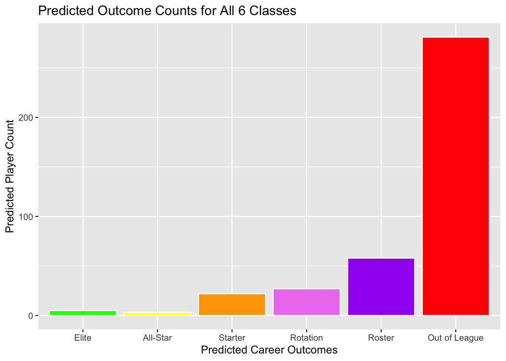

```r
###VISUALS FOR MODELING QUESTION####


#Predicted Outcome Counts Graph#

desired_order <- c("Elite", "All-Star", "Starter", "Rotation", "Roster", "Out of League")

outcome_predictions$testing_predictions <- factor(outcome_predictions$testing_predictions, levels = desired_order)



custom_colors <- c("Elite" = "green",
                   "All-Star" = "yellow",
                   "Starter" = "orange",
                   "Rotation" = "violet",
                   "Roster" = "purple",
                   "Out of League" = "red")

ggplot(outcome_predictions, aes(x = testing_predictions)) +
  geom_bar(stat = "count", fill = custom_colors, color = 'white') +
  labs(title = "Predicted Outcome Counts for All 6 Classes",
       x = 'Predicted Career Outcomes', y = "Predicted Player Count")
```

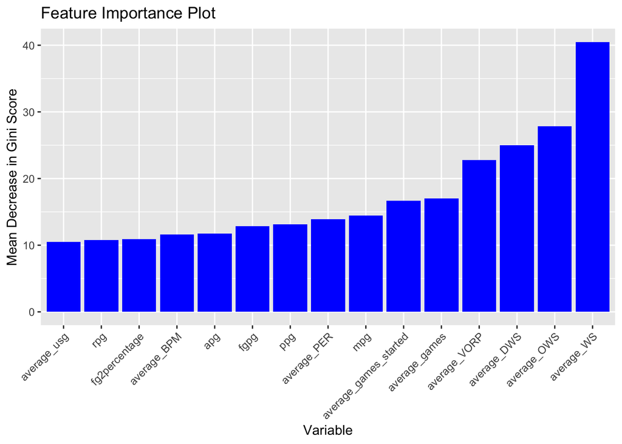

```r
###Importance of Variables in Random Forest Model###
variable_importance <- importance(rf_model)

variable_importance_df <- as.data.frame(variable_importance)

gini_threshold <- 10
important_vars <- variable_importance_df %>%
  filter(MeanDecreaseGini > gini_threshold)

ggplot(important_vars, aes(x = reorder(rownames(important_vars), MeanDecreaseGini), y = MeanDecreaseGini)) +
  geom_bar(stat = "identity", fill = "blue") +
  labs(title = "Feature Importance Plot",
       x = "Variable",
       y = "Mean Decrease in Gini Score") +
  theme(axis.text.x = element_text(angle = 45, hjust = 1))
```

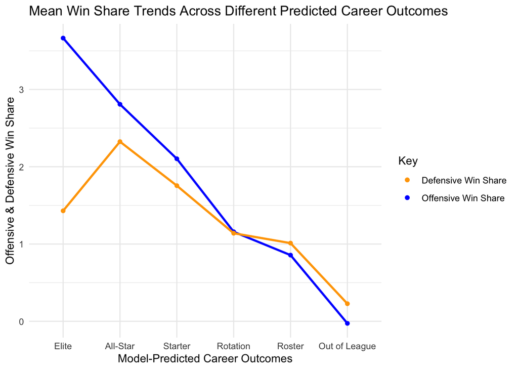

```r
stats_vs_outcomes_dataset <- left_join(total_predictions, testing_dataset_aggregated, by = "player")
View(stats_vs_outcomes_dataset)

win_shares_by_outcome <- stats_vs_outcomes_dataset %>%
  group_by(`Model Predictions`) %>%
  summarize(Offensive_Win_Share_by_Outcome = mean(average_OWS),
            Defensive_Win_Share_by_Outcome = mean(average_DWS))
View(win_shares_by_outcome)


outcome_order <- c("Elite", "All-Star", "Starter", "Rotation", "Roster", "Out of League")

win_shares_by_outcome$`Model Predictions` <- factor(win_shares_by_outcome$`Model Predictions`, levels = outcome_order)

ggplot(win_shares_by_outcome, aes(x = `Model Predictions`)) +
  geom_point(aes(y = Offensive_Win_Share_by_Outcome, color = "Offensive Win Share")) +
  geom_line(aes(y = Offensive_Win_Share_by_Outcome, group = 1), linewidth = 1, color = "blue") +
  geom_point(aes(y = Defensive_Win_Share_by_Outcome, color = "Defensive Win Share")) +
  geom_line(aes(y = Defensive_Win_Share_by_Outcome, group = 1), linewidth = 1, color = "orange") +
  labs(title = "Mean Win Share Trends Across Different Predicted Career Outcomes",
       x = "Model-Predicted Career Outcomes", y = "Offensive & Defensive Win Share") +
  scale_color_manual(name = "Key", values = c("Offensive Win Share" = "blue", "Defensive Win Share" = "orange")) +
  theme_minimal()
```

```r
### PREDICTIONS FOR SGA, ZION, WISEMAN, AND GIDDEY###


players_of_interest <- c("Shai Gilgeous-Alexander", "Zion Williamson", "James Wiseman", "Josh Giddey")

predictions_specific_players <- outcome_predictions %>%
  filter(player %in% players_of_interest)

predictions_specific_players
```

```
##                      player testing_predictions
## 159           James Wiseman       Out of League
## 201             Josh Giddey              Roster
## 337 Shai Gilgeous-Alexander            All-Star
## 395         Zion Williamson               Elite
```

```r
#If for any reason, the View() does not work, in order of SGA, Zion, Wiseman, and Giddey, my projections have them as all-star, elite, out of league, and roster, respectively.
```

```r
###BONUS: HTML TABLE WITH PREDICTIONS PLAYERS DRAFTED BETWEEN 2019-2021###

#I want to get all of the probabilities of each distinct outcome, as well as the predicted outcome for each player in one dataset. Important for next step#

total_predictions <- left_join(outcome_predictions, probability_predictions, by = "player")



#Now, I want to go back and merge this dataset that has the player name, probability of each outcome, and predicted outcome, with a previous dataset that also includes each players draft year#

##First, I'm going to make a copy of my master data set, filter for players drafted between 2018 and 2021, and just bring the variables 'player' and 'draftyear'##

HTML_player_dataset <- model_data %>%
  filter(draftyear >= 2018 & draftyear <= 2021) %>%
  select(player, draftyear)


#Now I merge the two datasets on their player so all 2018-2021 players will have player names, draft year, probabilities, and predictions. I will also group and filter so only one record shows per player, which would be their draft year.#

HTML_table_predictions <- left_join(total_predictions, HTML_player_dataset, by = 'player') %>%
  filter(draftyear >=2019) %>%
  group_by(player, draftyear) %>%
  filter(row_number() == 1) %>%
  ungroup()

View(HTML_table_predictions)


#I will install and load in reactable now#

library(reactable)

reactable(HTML_table_predictions)
```

| player | testing_predictions | All-Star | Elite | Out of League | Roster | Rotation | Starter | draftyear |
| --- | --- | --- | --- | --- | --- | --- | --- | --- |
| Aaron Henry | Out of League | 0 | 0 | 0.748 | 0.23 | 0.006 | 0.016 | 2021 |
| Aaron Nesmith | Out of League | 0 | 0 | 0.648 | 0.172 | 0.158 | 0.022 | 2020 |
| Aaron Wiggins | Rotation | 0 | 0 | 0.23 | 0.282 | 0.36 | 0.128 | 2021 |
| Adam Mokoka | Out of League | 0 | 0 | 0.964 | 0.028 | 0.008 | 0 | 2019 |
| Ade Murkey | Out of League | 0 | 0 | 1 | 0 | 0 | 0 | 2020 |
| Admiral Schofield | Out of League | 0 | 0 | 0.93 | 0.044 | 0.022 | 0.004 | 2019 |
| Ahmad Caver | Out of League | 0 | 0 | 0.908 | 0.082 | 0.006 | 0.004 | 2019 |
| Aleem Ford | Out of League | 0 | 0 | 0.746 | 0.166 | 0.034 | 0.054 | 2021 |
| Aleksej Pokusevski | Out of League | 0 | 0 | 0.526 | 0.23 | 0.188 | 0.056 | 2020 |
| Alen Smailagic | Out of League | 0 | 0 | 0.844 | 0.052 | 0.104 | 0 | 2019 |

[output cut: 284 more lines]

```r
#I didn't like the way the columns were named and want to make the table look a little bit more like a final presentation table. I had to search for how to work with reactable but I lelieve I got it to work!#


colnames(HTML_table_predictions)[1:9] <- c("Player", "Model-Based Predictions", "Elite", "All-Star", "Out of League", "Roster", "Rotation", "Starter", "Draft Year")

Final_HTML_table <- HTML_table_predictions[, c("Player", "Model-Based Predictions", "Elite", "All-Star", "Out of League", "Roster", "Rotation", "Starter", "Draft Year")]
Final_HTML_table$Elite <- round(Final_HTML_table$Elite, 2)
Final_HTML_table$'All-Star' <- round(Final_HTML_table$'All-Star', 2)
Final_HTML_table$Starter <- round(Final_HTML_table$Starter, 2)
Final_HTML_table$Rotation <- round(Final_HTML_table$Rotation, 2)
Final_HTML_table$Roster <- round(Final_HTML_table$Roster, 2)
Final_HTML_table$'Out of League' <- round(Final_HTML_table$'Out of League', 2)

reactable(Final_HTML_table,
  striped = TRUE,
  bordered = TRUE,
  highlight = TRUE,
  searchable = TRUE,
)
```

| Player | Model-Based Predictions | Elite | All-Star | Out of League | Roster | Rotation | Starter | Draft Year |
| --- | --- | --- | --- | --- | --- | --- | --- | --- |
| Aaron Henry | Out of League | 0 | 0 | 0.75 | 0.23 | 0.01 | 0.02 | 2021 |
| Aaron Nesmith | Out of League | 0 | 0 | 0.65 | 0.17 | 0.16 | 0.02 | 2020 |
| Aaron Wiggins | Rotation | 0 | 0 | 0.23 | 0.28 | 0.36 | 0.13 | 2021 |
| Adam Mokoka | Out of League | 0 | 0 | 0.96 | 0.03 | 0.01 | 0 | 2019 |
| Ade Murkey | Out of League | 0 | 0 | 1 | 0 | 0 | 0 | 2020 |
| Admiral Schofield | Out of League | 0 | 0 | 0.93 | 0.04 | 0.02 | 0 | 2019 |
| Ahmad Caver | Out of League | 0 | 0 | 0.91 | 0.08 | 0.01 | 0 | 2019 |
| Aleem Ford | Out of League | 0 | 0 | 0.75 | 0.17 | 0.03 | 0.05 | 2021 |
| Aleksej Pokusevski | Out of League | 0 | 0 | 0.53 | 0.23 | 0.19 | 0.06 | 2020 |
| Alen Smailagic | Out of League | 0 | 0 | 0.84 | 0.05 | 0.1 | 0 | 2019 |

[output cut: 284 more lines]

## Part 2 – Predicting Team Stats

In this section, we’re going to introduce a simple way to predict team offensive rebound percent in the next game and then discuss ways to improve those predictions.

### Question 1

Using the `rebounding_data` dataset, we’ll predict a team’s next game’s offensive rebounding percent to be their average offensive rebounding percent in all prior games. On a single game level, offensive rebounding percent is the number of offensive rebounds divided by their number offensive rebound “chances” (essentially the team’s missed shots). On a multi-game sample, it should be the total number of offensive rebounds divided by the total number of offensive rebound chances.

Please calculate what OKC’s predicted offensive rebound percent is for game 81 in the data. That is, use games 1-80 to predict game 81.

```r
#In summation, I took the team rebounding data, and filtered it only to show OKC's statistics by game. I then used the summarize function to add upp all offesive rbounds and all chances to get an offensive rebound across all games, and divided it to find OKC's offensive rebounding % in games 1-80, as well as its prediction in game 81.

thunder_rebounding <- rebounding_data %>%
  filter(team == 'OKC') %>%
  summarise(
    total_off_rebounds = sum(offensive_rebounds),
    total_off_rebounds_chances = sum(off_rebound_chances),
    game_81_oreb_precent = total_off_rebounds / total_off_rebounds_chances
  )

thunder_rebounding
```

```
## # A tibble: 1 × 3
##   total_off_rebounds total_off_rebounds_chances game_81_oreb_precent
##                <dbl>                      <dbl>                <dbl>
## 1               1226                       4237                0.289
```

**ANSWER 1:**

28.9%

### Question 2

There are a few limitations to the method we used above. For example, if a team has a great offensive rebounder who has played in most games this season but will be out due to an injury for the next game, we might reasonably predict a lower team offensive rebound percent for the next game.

Please discuss how you would think about changing our original model to better account for missing players. You do not have to write any code or implement any changes, and you can assume you have access to any reasonable data that isn’t provided in this project. Try to be clear and concise with your answer.

**ANSWER 2: While I believe that using team statistics can be very helpful to analyze trends and find general insights about the overall prowess of a team’s offensive rebounding ability, especially over a longer sample size of a full season 82 games, it should not be used it to predict a value for a single game if there are better measurables at hand. For example, within this situation of a great offensive rebounder missing for the 81st game but being present in most of the team previous games that contributed to the 81st game’s rebounding prediction, using individual player statistics to help add in a rough estimate of each player’s importance to their team’s offensive rebounding ability could help with the game-to-game variance in prediction. I was thinking it would be ideal to build a model using each player’s offensive rebounding statistics on a per game level. Such statistics could include total offensive rebounds per game, their contribution to total offensive rebounds when they are on the floor, the amount of minutes they play, and how much time do they spend within five feet of the basket on offense as a measure of how often they are looking to rebound, among others. Using these statistics could help build a model that analyzes these measures and determines each player’s level of contribution to the total offensive rebounding of the team.**

### Question 3

In question 2, you saw and discussed how to deal with one weakness of the model. For this question, please write about 1-3 other potential weaknesses of the simple average model you made in question 1 and discuss how you would deal with each of them. You may either explain a weakness and discuss how you’d fix that weakness, then move onto the next issue, or you can start by explaining multiple weaknesses with the original approach and discuss one overall modeling methodology you’d use that gets around most or all of them. Again, you do not need to write any code or implement any changes, and you can assume you have access to any reasonable data that isn’t provided in this project. Try to be clear and concise with your answer.

**ANSWER 3: Using averages of team statistics to predict the next game’s value is difficult as their is little to no information about the game-by-game changes to statistical output in an NBA season, as shown by the situation in Question 2 that mentioned a player being injured. It is also worth noting that who you are playing is very important in individual offensive rebounding statistics - certain teams have either more players with skills and physical attributes that gives them advantages on the glass, probably noticed through their team defensive rebounding numbers. The opponent may also have a coach that emphasizes a play style that limits second-chance opportunities based on their defensive positioning, or a combination of both skill and play style. This greatly affects the output of a team’s offensive rebounding game-by-game, and controlling a possible regression or model to have values on the opponents team defensive rebounding ability is imperative. This includes total defensive rebounding percentage and individual statistics that measure how valuable their individual players playing in the next game are to the teams overall defensive rebounding. A possible way to input this most efficiently could be to find a league average of total defensive rebounding based on defensive rebounding percentage and totals, and set that value equal to 1. Then if you are playing against a certain team and are aware of the availability of their players, using the individual player statistics to predict a value of defensive rebounding percentage will give you a better look at what their actual team defensive rebounds and percent should be, as compared to what you would have found if you just added together all of their prior games defensive rebounding numbers and chances and found an average. This new number, driven by individual player insights, similar to what I thought would make sense to use in question 2 in regards to your own team’s offensive rebounding statistics, could then be compared to the league average. Dividing the number found by the league average tells you in a percentage how much better or worse the opponent is than the league average. If the number is greater than 1, say 1.1, that means the opponent is 10% than what the model would normally suspect, so you may adjust our average offensive rebounding percentage to reflect playing a harder opponent. This is one way to go about inputting how important different opponents are on a game-by-game level to the variance in rebounding numbers, and how to possibly correct this in our basic dataset so as to alter our team’s predicted values as well. A second weakness may be how we are predicting our values. There are many other ways to predict and evaluate certain values, and using simple algebra using only two variables in the context of an NBA game is not ideal. For example, take using a multivariate regression analysis model. We can first find all of the data necessary to incorporate in our model. This could be individual player statistics and their sole value to their teams rebounding, both for our teams offensive rebounding and for opponents defensive rebounding. Adding certain attributes on a game-by-game level such as home versus away, how many days rest prior to the game a team had, what is a team pace-of-play, and how many different shots do they take per game (three pointers, mid ranges, free throws, and layups/dunks all are not created the same in the sake of offensive rebounding probability). All of these factors are super important to have in a larger offensive rebounding dataset, and to potentially use in a regression model that predicts a team offensive rebounding using all of these factors. The model will create coefficients that essentially display how much value each factor plays into total offensive rebounding per game, and most importantly this model allows you to plug in all the necessary values that change game by game to predict the next game’s rebounding value more precisely. If you know what team you are playing, where you are playing, if any specific player is unavailable on either team, and all of the prior rebounding statistics and shot statistics, the model will show a more accurate representation of offensive rebounding values for that game as compared to the method we used in the first question.**